# Social Network Analysis

Michaela Fricova

2/10/2023

## #2 Marriage and business networks of the Medicis

This project is the 2/8 part of my mini-series on social network analysis. The goal of this series is to start with the very basics of network analysis, such as with the concepts of centrality and assortativity, and progress towards more advanced topics, including Erdős-Rényi and Configuration models, as well as Exponential family random graphs. In this second project, I am focusing on the concept of network centrality, while analysing marriage and business networks of the Medicis. The **Medici family** was one of the most influential and controversial families in the history of the world. They were able to rise above all the other upper-class families of Florence and dominate the political and cultural scene in the city state. The Medici family was instrumental in the **rise of the Italian Renaissance** and they were deeply involved in shaping European culture and politics for more than 300 years. Yet, the family rose to power from a relative obscurity. Medicis only moved to Florence sometime in the 12th century and established a banking business in Florence in 1397 (Padgett and Ansell, 1993). This raises the question: how were Giovanni and his son Cosimo de’Medici able to turn their banking business into the top financial institution and **gain such overwhelming political influence over Florence**? Maybe their social networks can give us a hint.

### Loading libraries

I start by loading the necessary libraries.

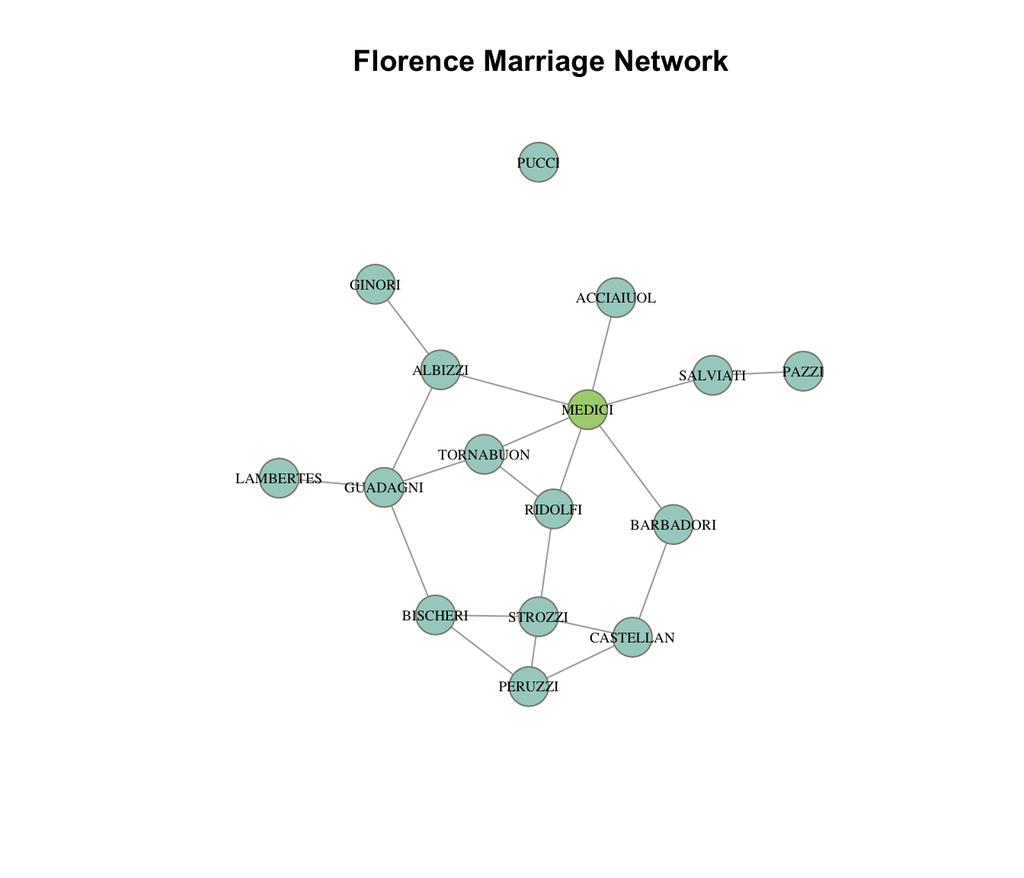

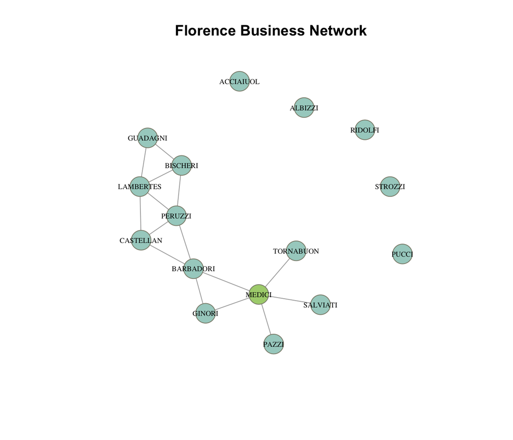

```r
#define vector of packages to load
some_packages <- c('RColorBrewer' ,'corrplot','biganalytics','tidyverse' ,'intergraph'
                   ,'igraph','reactable','data.table','dplyr' ,'tidyr','gridExtra'
                   ,'grid','png','downloader' ,'grDevices', 'ggpubr')

#load all packages at once
lapply(some_packages, library, character.only=TRUE)
```

The figures above outline links between the key families in Florence, whereby a link represents a marriage or a business relation between members of two families. Given that marriage and business relations are bi-directional by nature, the network edges are un-directed.

```r
centralities_name_df <- data.frame(nodes$nodeLabel, round(degree(flo_m),2), round(evcent(flo_m)$vector, 2), round(closeness(flo_m),5), round(betweenness(flo_m),2), round(degree(flo_b),2), round(evcent(flo_b)$vector,2), round(closeness(flo_b),5), round(betweenness(flo_b),2))
colnames(centralities_name_df) <- c('family name', 'degree marriage', 'eigenvector marriage', 'closeness marriage', 'betweeness marriage','degree business', 'eigenvector business', 'closeness business', 'betweeness business')

reactable(centralities_name_df,
          style = list(fontFamily = 'Menlo', fontSize = '10px'),
          defaultColDef =
            colDef(header = function(value) gsub(".", " ", value, fixed = TRUE),
                   cell = function(value) format(value, nsmall = 1),
                   align = "center",
                   minWidth = 70,
                   headerStyle = list(background = "#f7f7f8")
                   ),
            rowStyle = function(index) {
    if (centralities_name_df[index, "degree marriage"] > 5) {
      list(background = "#A6D0C8")
    }
  },
  rowClass = function(index) {
    if (centralities_name_df[index, "degree marriage"] < 5) {
      "bold"
    }
  }
)
```

| family name | degree marriage | eigenvector marriage | closeness marriage | betweeness marriage | degree business | eigenvector business | closeness business | betweeness business |
| --- | --- | --- | --- | --- | --- | --- | --- | --- |
| ACCIAIUOL | 1 | 0.31 | 0.01852 | 0 | 0 | 0 | 0.00417 | 0 |
| ALBIZZI | 3 | 0.57 | 0.02222 | 19.33 | 0 | 0 | 0.00417 | 0 |
| BARBADORI | 2 | 0.49 | 0.02083 | 8.5 | 4 | 0.83 | 0.01031 | 25 |
| BISCHERI | 3 | 0.66 | 0.01961 | 9.5 | 3 | 0.73 | 0.00952 | 2.5 |
| CASTELLAN | 3 | 0.6 | 0.01923 | 5 | 3 | 0.83 | 0.01 | 5 |
| GINORI | 1 | 0.17 | 0.01724 | 0 | 2 | 0.4 | 0.0098 | 0 |
| GUADAGNI | 4 | 0.67 | 0.02174 | 23.17 | 2 | 0.5 | 0.00893 | 0 |
| LAMBERTES | 1 | 0.21 | 0.01695 | 0 | 4 | 0.92 | 0.00962 | 6 |
| MEDICI | 6 | 1 | 0.02439 | 47.5 | 5 | 0.51 | 0.0101 | 24 |
| PAZZI | 1 | 0.1 | 0.01538 | 0 | 1 | 0.15 | 0.00926 | 0 |

[output cut: 6 more lines]

Closeness centrality is a useful measure that estimates how fast the flow of information would be through a given node to other nodes (calculated using shortest geodesic distance). Given that the Medicis have the highest closeness centrality in the marriage network - although tightly followed by the Guadagni and Albizzi - it appears that the family had great access to information (Newman, 2010). Also in the business network did the Medicis come among the top families in the closeness centrality.

Finally the relatively high betweeness of the Medicis suggests that the Medicis not only could readily access to information, but that they also influenced what information gets passed on to less interconnected families in the network. The concept of the betweeness centrality is related to that of a bridge. Nodes that have high betweenness centraility tend to bridge otherwise disconnected nodes. This way they can receive unique information and also substantially influence the network.

```r
centralities_df <- data.frame(round(degree(flo_m),2), round(evcent(flo_m)$vector, 2), round(closeness(flo_m),2), round(betweenness(flo_m),2), round(degree(flo_b),2), round(evcent(flo_b)$vector,2), round(closeness(flo_b),2), round(betweenness(flo_b),2))
```

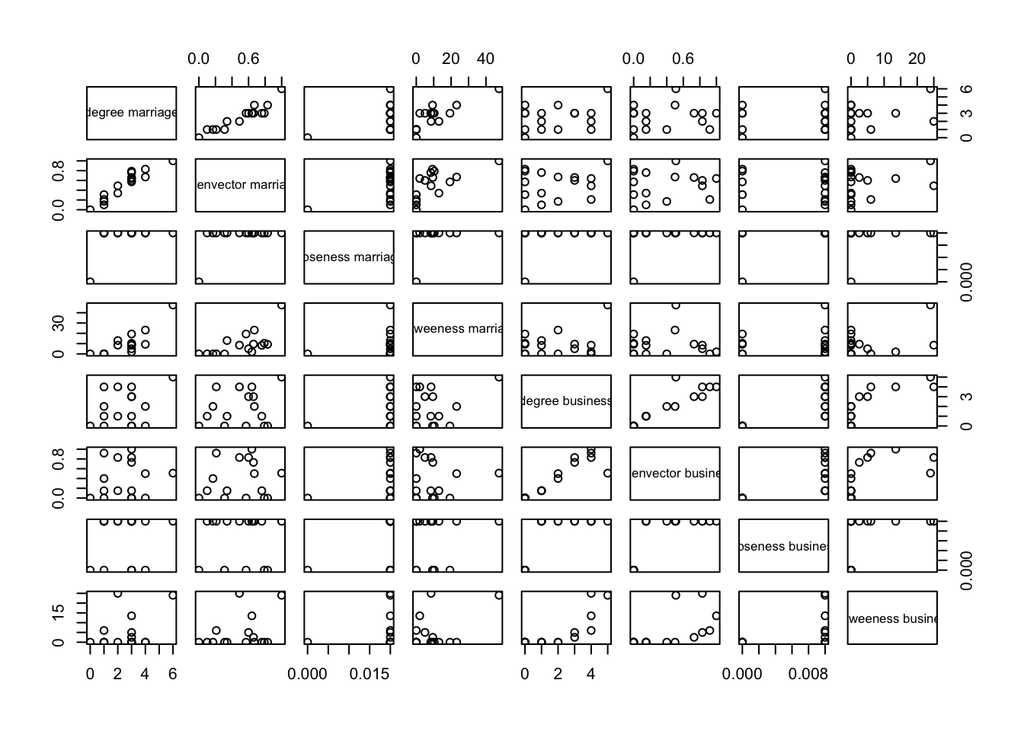

```r
colnames(centralities_df) <- c('degree marriage', 'eigenvector marriage', 'closeness marriage', 'betweeness marriage','degree business', 'eigenvector business', 'closeness business', 'betweeness business')
plot(centralities_df)
```

```r
cors <- cor(centralities_df, method = "pearson")
print(cors)
```

```
##                      degree marriage eigenvector marriage closeness marriage
## degree marriage            1.0000000           0.93996026          0.4428074
## eigenvector marriage       0.9399603           1.00000000          0.4675058
## closeness marriage         0.4428074           0.46750582          1.0000000
## betweeness marriage        0.8333520           0.67333287          0.2113574
## degree business            0.3296160           0.23118946          0.2862992
## eigenvector business       0.1409071           0.10626829          0.2738318
## closeness business         0.1387492           0.02099544          0.3829708
## betweeness business        0.3792886           0.32711044          0.1486259
##                      betweeness marriage degree business eigenvector business
## degree marriage               0.83335204       0.3296160           0.14090709
## eigenvector marriage          0.67333287       0.2311895           0.10626829
## closeness marriage            0.21135741       0.2862992           0.27383183
## betweeness marriage           1.00000000       0.3047141          -0.01449194
## degree business               0.30471408       1.0000000           0.90583161
## eigenvector business         -0.01449194       0.9058316           1.00000000
## closeness business            0.11046272       0.7475743           0.71502006
## betweeness business           0.43707653       0.7972799           0.59735439
##                      closeness business betweeness business
## degree marriage              0.13874919           0.3792886
## eigenvector marriage         0.02099544           0.3271104
## closeness marriage           0.38297084           0.1486259
## betweeness marriage          0.11046272           0.4370765
## degree business              0.74757432           0.7972799
## eigenvector business         0.71502006           0.5973544
## closeness business           1.00000000           0.3880866
## betweeness business          0.38808660           1.0000000
```

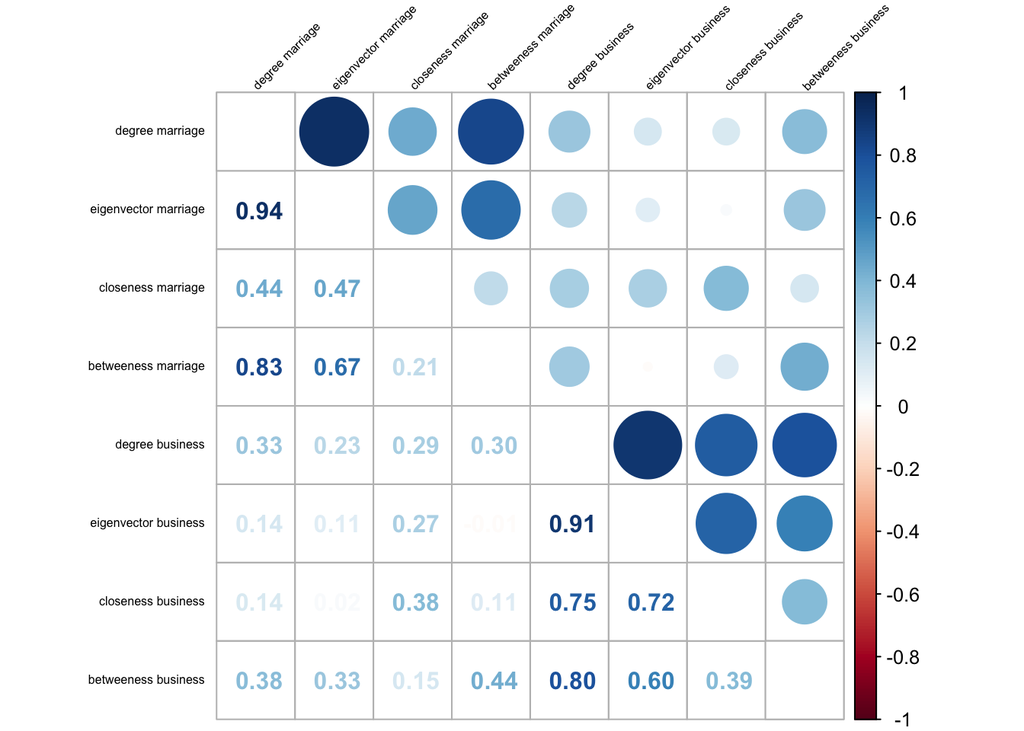

```r
corrplot.mixed(cors, tl.col = "black", tl.cex =0.5, tl.srt=45, tl.pos='lt')
```

We find varied Pearson’s correlations among the 8 centrality measures presented here. But, in vast majority of cases, the 8 centrality measures are positively correlated. The 2 most closely correlated metrics are (1) Degree centrality and (2) Eigenvector centrality in the marriage network.These 2 metrics have a strong positive correlation of approximately 0.94. This high correlation is congruent with the fact that Degree and Eigenvector centrality are theoretically interlinked concepts. Both Degree and Eigenvector centrality depict the prestige, influence and access to information among network nodes. They both consider the number of direct connections that a node has, although Eigenvector centrality extends on this by also measuring the relative importance of each immediate connection.

```r
graph.density(flo_m)
```

```
## [1] 0.1666667
```

```r
graph.density(flo_b)
```

```
## [1] 0.125
```

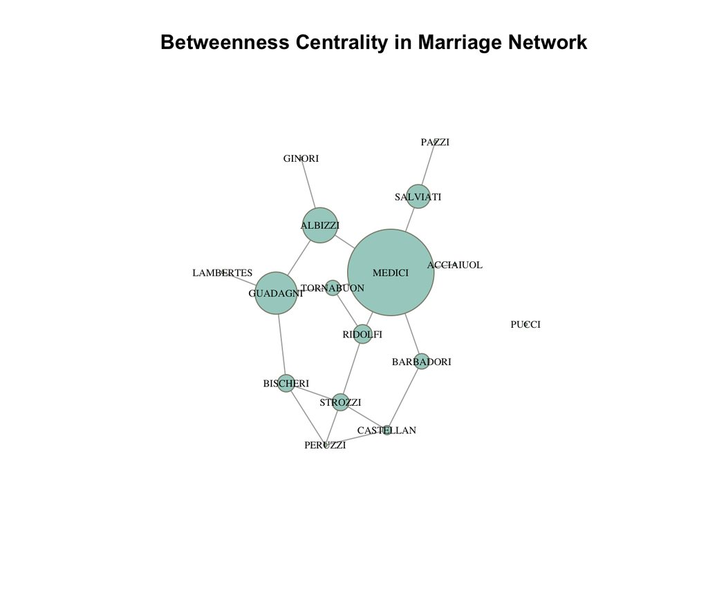

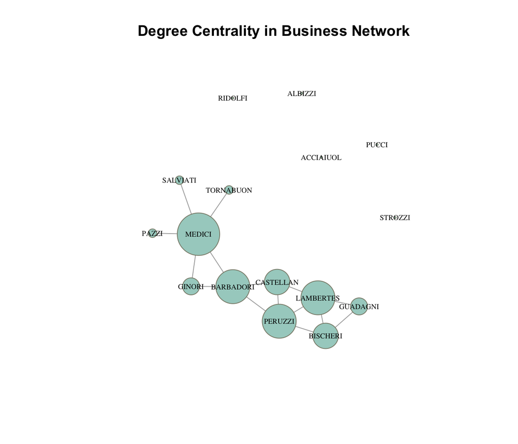

If we estimate the importance of elite Florentine families simply by the degree centrality in the marriage network, i.e. how many families a given family is linked to through marriages, then the Medici do come out as the most important ones. But they only surpass the next highest families, such as the Strozzis, by a ratio of 3 to 2. And similarly tied findings are also reported for measures of closeness centrality and Eigenvector centrality. There must, therefore, be other factors at play behind the enormous success of the Medicis. And this appears to be, in part, betweenness centrality. Raw betweenness centrality asks: what is the total number of geodesics (shortest paths) going through a given vertex? In our marriage network, we see that Medicis have by far the highest raw betweenness. In fact, approximately 47 different geodesics go through family Medici. The second highest betweenness centrality is only less than half that of Medicis, i.e. family Guadagni with raw betweenness centrality of 23.16 paths.

The concept of betweenness centrality was originally proposed by Freeman in 1977 (although Freeman himself pointed out that a similar concept was previously introduced by Anthonisse) (Newman, 2010). Freeman’s approach to betweenness was built on the concept of local dependency. A point is dependent on another if the paths that connect it to others pass through this point. And this is also partially the idea behind Burt’s (1992) ‘Structural Holes Theory’. By structural hole, Burt refers to an ‘empty space’ between contacts in a person’s network. It means that these contacts are disconnected, they do not interact closely (though they may be aware of one another). For example, there is a structural hole between family Pucci and all other elite Florentine families in the marriage network, since family Pucci does not hold any marriage ties with the other families. Furthermore, Burt (2004) links structural holes to the concept of network social capital, whereby he defines network social capital as “the contextual complement to human capital.” And he further postulates that “social capital predicts that returns to intelligence, education and seniority depend in some part on a person’s location in the social structure of a hierarchy.” The Structural Holes Theory has an openness approach to social capital, it describes social capital as a function of the brokerage opportunities in a network. And d it draws on Granovetter’s (1973) strength of weak ties whereby weak ties bridge across homogeneous social network components and, hence, provide cohesion in the society.

In our example, the family Medici had relationships that spanned the marriage network structural holes, i.e. they took the broker position between the large network component (with family Strozzi) and less inter-tied families Acciaiuoli, Salviati and Pazzi. According to the Structural Hole Theory, this brought them the opportunity to acquire non-redundant pieces of information from the different marriage ties and determine what gets relayed to the main component of the network. It is probable that each cluster of direct contacts constituted a single information source because families with direct marriage connections tend to have the same information at the same time. By being brokers, Medicis were the only family with direct access to unique information from family Acciaiuoli and they also had the valuable link to relatively isolated family Salviati. These constituted non-redundant information sources also provided Medicis with broader information screen and hence ensured that the family was well-informed of impeding disasters. Likewise, the Medicis’ high betweenness centrality ensured that the family was the first to see new business opportunities in different parts of the network. A related concept to such ‘information’ subtype of social capital is ‘coordination’ social capital (Jackson, 2019). It can be defined as being situated as a ‘friend-in-common’ and so being in the position to coordinate others, combine the forces of families which would not otherwise have come together. Since family Medici served as a bridge of other elite families, they were in the position to coordinate the Florentine oligarchy and their behavior. This might also explain why the family Medici was comparatively more politically successful and better equipped to coordinate armed men, relative to their rival families Strozzi and Albizzi.

```r
degrees_df <- data.frame(nodes$nodeLabel, (degree(flo_m) + degree(flo_b) ))
colnames(degrees_df) <- c('family name', 'degree marriage plus business')

reactable(degrees_df,
          style = list(fontFamily = 'Menlo', fontSize = '10px'),
          defaultColDef =
            colDef(header = function(value) gsub(".", " ", value, fixed = TRUE),
                   cell = function(value) format(value, nsmall = 1),
                   align = "center",
                   minWidth = 70,
                   headerStyle = list(background = "#f7f7f8")
                   ),
            rowStyle = function(index) {
    if (degrees_df[index, 'degree marriage plus business'] > 10) {
      list(background = "#A6D0C8")
    }
  },
  rowClass = function(index) {
    if (degrees_df[index, 'degree marriage plus business'] < 10) {
      "bold"
    }
  }
)
```

| family name | degree marriage plus business |
| --- | --- |
| ACCIAIUOL | 1 |
| ALBIZZI | 3 |
| BARBADORI | 6 |
| BISCHERI | 6 |
| CASTELLAN | 6 |
| GINORI | 3 |
| GUADAGNI | 6 |
| LAMBERTES | 5 |
| MEDICI | 11 |
| PAZZI | 2 |

[output cut: 6 more lines]

Furthermore, the Medicis’ power position in the marriage network might have been further strengthened by their ties in the business network. Holler (2020) brings forward the observation that the Medici did not marry from those families with whom they engaged in business relations, nor did they do business with those whom they married. According to Padgett and Ansell (1993), Medicis married into families from different neighborhoods than the Medici, while they formed business ties with families living close to them. I have, therefore, complemented the graph of betweenness centrality in the marriage network with a graph of degree centrality in the business network. The Medici have 11 (either marriage or business) edges connected to theim in total – more than any other elite family. And they also have the most diversified links. Out of the 11 total, 5 links are either marriage links or business links, but not both. We also see that for families Pazzi, Salviati and Tornabuoni, the business link with family Medici constituted the only connection to the main business network component. Therefore, the families Pazzi, Salviati and Tornabuoni were solely dependent on the Medici and likely created strong, close ties with the Medici family. This relates to the concepts of bonding and closure social capital (Burt, 2001). Such closed network structures are constituted of strong ties and they are associated with some positive consequences. For example, members of closed network structures feel obligated to help one another in times of a crisis (Prell, 2009). This might help explain why Cosimo de’Medici received some much help from his friends after he was imprisoned in 1433 (Padgett and Ansell, 1993). Taken together, the mixing of strong ties with geography and social class might have brought the Medici an extremely profitable mixed structure of both closure and openness social capital. Through this position, the Medici arguably cemented together the overall elite family network and strengthened their power in Florence.

### References

Breiger, R.L. and Pattison, P.E., 1986. Cumulated social roles: The duality of persons and their algebras. Social networks, 8(3), pp.215-256.

Burt, R.S., 1998. The gender of social capital. Rationality and society, 10(1), pp.5-46.

Burt, R.S., 2001. Closure as social capital. Social capital: Theory and research, pp.31-55.

Burt, R.S., 2004. Structural holes and good ideas. American journal of sociology 110, no. 2 (2004): 349-399.

Csardi, M.G., 2013. Package ‘igraph’. Project CRAN.

Granovetter, M.S., 1973. The strength of weak ties. American journal of sociology, 78(6), pp.1360-1380.

Holler, M., 2020. Power in Networks: The Medici. Available at SSRN 3673940.

Jackson, M.O., 2019. A typology of social capital and associated network measures. Social Choice and Welfare, pp.1-26.

Newman, M., 2010. Networks. Oxford university press.

Padgett, J.F. and Ansell, C.K., 1993. Robust Action and the Rise of the Medici, 1400-1434. American journal of sociology, 98(6), pp.1259-1319.

Prell, C., 2009. Linking social capital to small-worlds: a look at local and network-level processes and structure. Methodological innovations online, 4(1), pp.8-22.